# NLP PROJECT 2 UPENDRAN

```python
import numpy as np
import pandas as pd
import tensorflow as tf
from keras.datasets import imdb
import string
from tensorflow.keras.utils import plot_model
```

## Load the dataset

```python
df = tf.keras.datasets.imdb.load_data(path="imdb.npz",
    num_words=None,
    skip_top=0,
    maxlen=None,
    seed=113,
    start_char=1,
    oov_char=2,
    index_from=3)
```

```python
from keras.preprocessing.sequence import pad_sequences
vocab_size = 10000 #vocab size
maxlen = 300
```

```python
#load dataset as a list of ints
(x_train, y_train), (x_test, y_test) = imdb.load_data(num_words=vocab_size)
#make all sequences of the same length
x_train = pad_sequences(x_train, maxlen=maxlen)
x_test =  pad_sequences(x_test, maxlen=maxlen)
```

```python
print(x_train[1])
```

```
[   0    0    0    0    0    0    0    0    0    0    0    0    0    0
    0    0    0    0    0    0    0    0    0    0    0    0    0    0
    0    0    0    0    0    0    0    0    0    0    0    0    0    0
    0    0    0    0    0    0    0    0    0    0    0    0    0    0
    0    0    0    0    0    0    0    0    0    0    0    0    0    0
    0    0    0    0    0    0    0    0    0    0    0    0    0    0
    0    0    0    0    0    0    0    0    0    0    0    0    0    0
    0    0    0    0    0    0    0    0    0    0    0    0    0    1
  194 1153  194 8255   78  228    5    6 1463 4369 5012  134   26    4
  715    8  118 1634   14  394   20   13  119  954  189  102    5  207
  110 3103   21   14   69  188    8   30   23    7    4  249  126   93
    4  114    9 2300 1523    5  647    4  116    9   35 8163    4  229
    9  340 1322    4  118    9    4  130 4901   19    4 1002    5   89
   29  952   46   37    4  455    9   45   43   38 1543 1905  398    4
 1649   26 6853    5  163   11 3215    2    4 1153    9  194  775    7
 8255    2  349 2637  148  605    2 8003   15  123  125   68    2 6853
   15  349  165 4362   98    5    4  228    9   43    2 1157   15  299
  120    5  120  174   11  220  175  136   50    9 4373  228 8255    5
    2  656  245 2350    5    4 9837  131  152  491   18    2   32 7464
 1212   14    9    6  371   78   22  625   64 1382    9    8  168  145
   23    4 1690   15   16    4 1355    5   28    6   52  154  462   33
   89   78  285   16  145   95]
```

```python
print(x_train[1].shape)
```

```
(300,)
```

```python
print(y_train[1])
```

```
0
```

```python
len(y_train)
```

```
25000
```

```python
word_index = imdb.get_word_index()
```

```
Downloading data from https://storage.googleapis.com/tensorflow/tf-keras-datasets/imdb_word_index.json
```

```python
word_dict = imdb.get_word_index()
word_dict = { key:(value + 3) for key, value in word_dict.items() }
word_dict[''] = 0                                                    # Padding
word_dict['>'] = 1                                                   # Start
word_dict['?'] = 2                                                   # Unknown word
reverse_word_dict = { value:key for key, value in word_dict.items() }
print(' '.join(reverse_word_dict[id] for id in x_train[0]))
```

```
                                                                                  > this film was just brilliant casting location scenery story direction everyone's really suited the part they played and you could just imagine being there robert ? is an amazing actor and now the same being director …
```

```python
from keras.models import Sequential
from keras.layers import Dense, Input
from keras.layers.embeddings import Embedding
from keras.preprocessing import sequence
from keras.layers import LSTM
### create the model
model = Sequential()
model.add(Embedding(vocab_size, 128, trainable=True, input_length=maxlen))
model.add(LSTM(units=64, dropout=0.2))
model.add(Dense(32, activation='relu'))
model.add(Dense(1, activation='sigmoid'))
model.compile(loss='binary_crossentropy', optimizer='adam', metrics=['accuracy'])
model.summary()
```

```
Model: "sequential"
_________________________________________________________________
 Layer (type)                Output Shape              Param #
=================================================================
 embedding (Embedding)       (None, 300, 128)          1280000

 lstm (LSTM)                 (None, 64)                49408

 dense (Dense)               (None, 32)                2080

 dense_1 (Dense)             (None, 1)                 33

=================================================================
Total params: 1,331,521
Trainable params: 1,331,521
Non-trainable params: 0
_________________________________________________________________
```

```python
### Fit the model
model.fit(x_train, y_train, validation_data=(x_test, y_test), epochs=10, batch_size=500, verbose=1)
```

```
<keras.callbacks.History at 0x20ab65e67c0>
```

```python
model.fit(x_train, y_train, validation_data=(x_test, y_test), epochs=5, initial_epoch=20,batch_size=500, verbose=1)
```

```
<keras.callbacks.History at 0x20aa30fc3a0>
```

```python
# Final evaluation of the model
scores = model.evaluate(x_test, y_test, verbose=0)
print("Accuracy: %.2f%%" % (scores[1]*100))
```

```
Accuracy: 84.02%
```

## Prediction

```python
y_pred = model.predict(x_test)
```

```python
y_pred[70]
```

```
array([0.9996026], dtype=float32)
```

```python
top_words = vocab_size
def analyze(text):
    # Prepare the input by removing punctuation characters, converting
    # characters to lower case, and removing words containing numbers
    translator = str.maketrans('', '', string.punctuation)
    text = text.translate(translator)
    text = text.lower().split(' ')
    text = [word for word in text if word.isalpha()]

    # Generate an input tensor
    input = [1]
    for word in text:
        if word in word_dict and word_dict[word] < top_words:
            input.append(word_dict[word])
        else:
            input.append(2)
    padded_input = sequence.pad_sequences([input], maxlen=maxlen)

    # Invoke the model and return the result
    result = model.predict(np.array([padded_input][0]))[0][0]
    return result
```

```python
analyze('Easily the most stellar experience I have ever had.')
```

```
0.9985658
```

```python
analyze("movie is so worst")
```

```
0.01587826
```

# Part 2 SOCIAL MEDIA ANALYSIS

```python
import tensorflow as tf
from tensorflow.keras.preprocessing.text import Tokenizer
from tensorflow.keras.preprocessing.sequence import pad_sequences
```

```python
# Reading the json raw file
# import json

# def parse_data(file):
#     for l in open(file,'r'):
#         yield json.loads(l)

# data = list(parse_data('Sarcasm_Headlines_Dataset.json'))
```

```python
#reading the json fill in pandas dataframe
import pandas as pd
data = pd.read_json("Sarcasm_Headlines_Dataset.json",lines=True)
```

```python
data.head()
```

|  | article_link | headline | is_sarcastic |
| --- | --- | --- | --- |
| 0 | https://www.huffingtonpost.com/entry/versace-b... | former versace store clerk sues over secret 'b... | 0 |
| 1 | https://www.huffingtonpost.com/entry/roseanne-... | the 'roseanne' revival catches up to our thorn... | 0 |
| 2 | https://local.theonion.com/mom-starting-to-fea... | mom starting to fear son's web series closest ... | 1 |
| 3 | https://politics.theonion.com/boehner-just-wan... | boehner just wants wife to listen, not come up... | 1 |
| 4 | https://www.huffingtonpost.com/entry/jk-rowlin... | j.k. rowling wishes snape happy birthday in th... | 0 |

**Dropping article_link from dataset, since it is not significant**

```python
del data['article_link']
```

```python
#final dataset
data.head()
```

|  | headline | is_sarcastic |
| --- | --- | --- |
| 0 | former versace store clerk sues over secret 'b... | 0 |
| 1 | the 'roseanne' revival catches up to our thorn... | 0 |
| 2 | mom starting to fear son's web series closest ... | 1 |
| 3 | boehner just wants wife to listen, not come up... | 1 |
| 4 | j.k. rowling wishes snape happy birthday in th... | 0 |

```python
#Got length of each headline and add a column for the same.
data['sentence-length'] = data['headline'].apply(lambda x: len(x))
```

```python
data.head()
```

|  | headline | is_sarcastic | sentence-length |
| --- | --- | --- | --- |
| 0 | former versace store clerk sues over secret 'b... | 0 | 78 |
| 1 | the 'roseanne' revival catches up to our thorn... | 0 | 84 |
| 2 | mom starting to fear son's web series closest ... | 1 | 79 |
| 3 | boehner just wants wife to listen, not come up... | 1 | 84 |
| 4 | j.k. rowling wishes snape happy birthday in th... | 0 | 64 |

```python
data['headline'][0]
```

```
"former versace store clerk sues over secret 'black code' for minority shoppers"
```

## EDA

```python
data1= data.copy()
```

```python
#import necessary library
import re
from nltk.corpus import stopwords

set_stopwords = set(stopwords.words("english"))


def clean_txt(text): # define the fuction with tokenization/string cleaning for all datasets

    text = re.sub(r"[^A-Za-z,!?]", " ", text)
    text = re.sub(r'\[[^]]*\]'," ", text)
    text = re.sub(r"\'s", "", text)
    text = re.sub(r"\'t", "", text )
    text = re.sub(r"\'re", "",text)
    text = re.sub(r"\'d", "", text)
    text = re.sub(r"\'ll", " ",text)
    text = re.sub(r",", " ", text)
    text = re.sub(r"\(", " ", text)
    text = re.sub(r"\)", " ", text)
    text = re.sub(r"\'", " ", text)
    text = re.sub(r"aa", "", text)
    text = re.sub(r"zz", "", text)
    text = re.sub(r"[0-9]", ' ', text)
    text = text.lower()
    text = ' '.join(word for word in text.split() if word not in set_stopwords)
    return text

data1['headline'] = data1['headline'].apply(clean_txt)
```

```python
data_clean_len = data1['headline'].apply(lambda x: len(x.split(' '))).sum()
print(f'After text cleaning we have only {data_clean_len} words to work with')
```

```
After text cleaning we have only 187986 words to work with
```

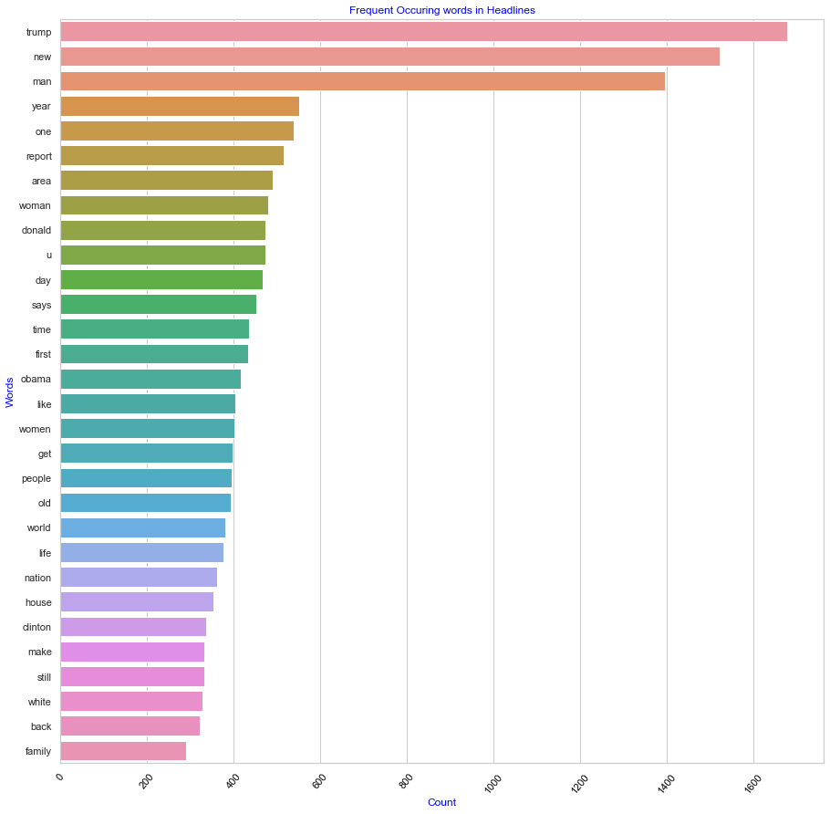

```python
from collections import Counter #import Counter for finding most common words
import seaborn as sns #import searbon for vizualization result

text = data1['headline']
words = text.str.split(expand=True).unstack()
result_count = Counter(words).most_common()
result_df = pd.DataFrame(result_count).reset_index().drop(0) #converting to Dataframe and drop the Nones values
#result_df
#vizualize result
sns.set_theme(style="whitegrid")
f, ax = plt.subplots(figsize=(15, 15))
sns.barplot(y=result_df[0][0:30], x=result_df[1][0:30], data=result_df, palette=None)
plt.ylabel('Words', color="blue")  # Add an x-label to the axes.
plt.xlabel('Count', color="blue")  # Add a y-label to the axes.
plt.title("Frequent Occuring words in Headlines", color="blue")
plt.xticks(rotation=50);
ax.tick_params(axis='x', colors='black')
plt.show()
```

```python
#create DataFrame for sarcastic words
sarcastic = pd.DataFrame(data1[data1['is_sarcastic']==1]['headline'].str.split(expand=True).unstack().value_counts()).reset_index()
```

```python
#create DataFrame for non_sarcastic words
non_sarcastic = pd.DataFrame(data1[data1['is_sarcastic']==0]['headline'].str.split(expand=True).unstack().value_counts()).reset_index()
```

```python
from nltk.corpus import stopwords
stopwords = stopwords.words('english')

sarcasctic_2 = [every_word.lower() for every_word in sarcastic['index']]

sarc_nonstop = [word for word in sarcasctic_2 if word not in stopwords]

non_sarcasctic_2 = [every_word.lower() for every_word in non_sarcastic['index']]

non_sarc_nonstop = [word for word in non_sarcasctic_2 if word not in stopwords]
```

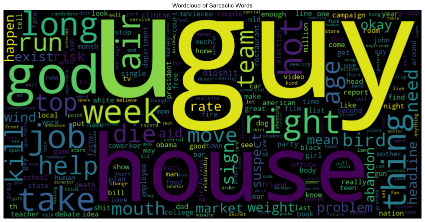

```python
#!pip install wordcloud
from wordcloud import WordCloud, STOPWORDS

plt.figure(figsize=(15,10))
wordcloud = WordCloud(width=1000, height=500,
                      max_words=300, min_font_size = 10,
                      background_color="black",
                      stopwords = stopwords,
                      ).generate(' ' .join(word for word in sarc_nonstop))

plt.imshow(wordcloud, interpolation='bilinear')
plt.title('Wordcloud of Sarcactic Words', color="black")
plt.axis("off")
plt.show()
```

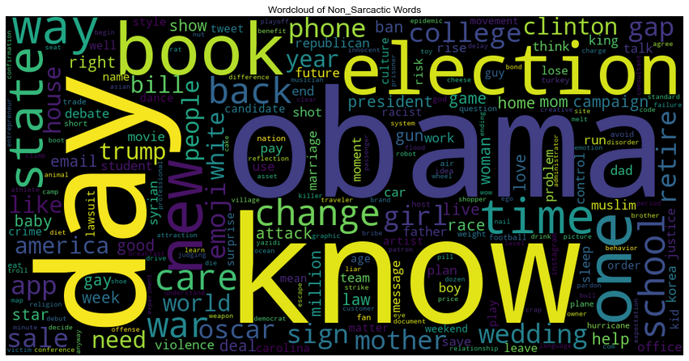

```python
from wordcloud import WordCloud, STOPWORDS

plt.figure(figsize=(15,10))
wordcloud = WordCloud(width=1000, height=500,
                      max_words=300, min_font_size = 10,
                      background_color="black",
                      stopwords = stopwords,
                      ).generate(' ' .join(word for word in non_sarc_nonstop))

plt.imshow(wordcloud, interpolation='spline36')
plt.title('Wordcloud of Non_Sarcactic Words', color="black")
plt.axis("off")
plt.show()
```

**Initializing parameter values**

```
-Set values for max_features, maxlen, & embedding_size
```

> max_features: Number of words to take from tokenizer(most frequent words)

> maxlen: Maximum length of each sentence is limited to 25

> embedding_size: size of embedding vector

```python
max_features = 10000
maxlen = 25
embedding_size = 100
```

**Applied tensorflow.keras Tokenizer and get indices for words**

Fit the tokenizer object on headline column

Converted the text to sequence

```python
tokenizer = Tokenizer() #create tokenizer object
tokenizer.fit_on_texts(data['headline']) #create word index dict

word_index_dict = tokenizer.word_index #get word index dict
vocab_size = len(word_index_dict) + 1

vocab_size
```

```
29657
```

```python
tokenizer.word_index #Most frequent used words
```

[output not shown]

[output cut: 946 more lines]

```
 'website': 987,
 'pick': 988,
 'explains': 989,
 'table': 990,
 'energy': 991,
 'users': 992,
 'feeling': 993,
 'sales': 994,
 'colbert': 995,
 'apparently': 996,
 "let's": 997,
 'amazing': 998,
 'went': 999,
 'budget': 1000,
 ...}
```

**Pad sequences**

Pad each example with a maximum length Convert target column into numpy array

```python
sequence = tokenizer.texts_to_sequences(data['headline'])

padding = pad_sequences(sequences=sequence, maxlen=maxlen)
```

```python
training_size = len(data)
test_portion = 0.3
split = int(test_portion*training_size)
split
test_sequences = padding[0:split]
training_sequences = padding[split:]

labels = data['is_sarcastic']

test_labels = labels[0:split]
training_labels = labels[split:]
```

```python
print(test_labels.shape)
print(training_labels.shape)
```

```
(8012,)
(18697,)
```

```python
# Vocab Size
vocab_size
```

```
29657
```

```python
num_words = len(tokenizer.word_index) + 1
print(num_words)
```

```
29657
```

```python
#loading pre-trained glove file
glove_file = 'C:/Users/AI_SG/Documents/Upendran/Course/python/Projects/NLP/W6 NLP Projects/glove.6B.100d.txt'
```

```python
import numpy as np

embeddings_index = {}
f = open(glove_file, encoding="utf8")
for line in f:
    values = line.split()
    word = values[0]
    coefs = np.asarray(values[1:], dtype='float32')
    embeddings_index[word] = coefs
f.close()
```

```python
import numpy as np

EMBEDDING_FILE = 'glove.6B.100d.txt'

embeddings = {}
for o in open(EMBEDDING_FILE,encoding="utf8"):
    word = o.split(" ")[0]
    # print(word)
    embd = o.split(" ")[1:]
    embd = np.asarray(embd, dtype='float32')
    # print(embd)
    embeddings[word] = embd

# create a weight matrix for words in training docs
embedding_matrix = np.zeros((num_words, 100))

for word, i in tokenizer.word_index.items():
	embedding_vector = embeddings.get(word)
	if embedding_vector is not None:
		embedding_matrix[i] = embedding_vector
```

## Defined model

**Used Sequential model instance and then add Embedding layer, Bidirectional(LSTM) layer, flatten it, then dense and dropout layers as required. -In the end added a final dense layer with sigmoid activation for binary classification.**

```python
import keras
from keras.models import Sequential
from keras.layers import Dense,Embedding,LSTM,Dropout,Bidirectional,Flatten
embedding_dim = embedding_size
#Defining Neural Network
model = Sequential()
#Non-trainable embeddidng layer
model.add(Embedding(num_words, embedding_dim, weights=[embedding_matrix], input_length=maxlen))
#LSTM
model.add(Bidirectional(LSTM(units=128 ,dropout = 0.5,return_sequences=True)))
model.add(Flatten())
model.add(Dense(1, activation='sigmoid'))
model.summary()
```

```
Model: "sequential_1"
_________________________________________________________________
 Layer (type)                Output Shape              Param #
=================================================================
 embedding_1 (Embedding)     (None, 25, 100)           2965700

 bidirectional (Bidirectiona  (None, 25, 256)          234496
 l)

 flatten (Flatten)           (None, 6400)              0

 dense (Dense)               (None, 1)                 6401

=================================================================
Total params: 3,206,597
Trainable params: 3,206,597
Non-trainable params: 0
_________________________________________________________________
```

```python
print('training_sentences : ',test_sequences .shape)
print('testing_sentences : ',training_sequences .shape)
print('training_labels : ',training_labels.shape)
print('testing_labels : ',test_labels.shape)
```

```
training_sentences :  (8012, 25)
testing_sentences :  (18697, 25)
training_labels :  (18697,)
testing_labels :  (8012,)
```

```python
#Model Compilation
from tensorflow import keras

opt = keras.optimizers.Adam(learning_rate=0.01)
model.compile(optimizer=opt, loss='binary_crossentropy', metrics=["accuracy"])
```

```python
# Fit the model

training_sequences = np.array(training_sequences)
training_labels = np.array(training_labels)
test_sequences = np.array(test_sequences)
test_labels = np.array(test_labels)
```

```python
history = model.fit(x=training_sequences, y=training_labels, validation_data=(test_sequences, test_labels), epochs = 10, verbose = 1)
```

```python
#Test accuracy
print("Test-Accuracy:", np.mean(history.history["val_accuracy"]))
```

```
Test-Accuracy: 0.845544183254242
```

```python
scores = model.evaluate(test_sequences, test_labels, verbose=0)
print("Accuracy: %.5f%%" % (scores[1]*100))
```

```
Accuracy: 84.64803%
```

# Tuning 1

```python
model_1 = Sequential()
#Non-trainable embeddidng layer
model_1.add(Embedding(num_words, embedding_dim, weights=[embedding_matrix], input_length=maxlen))
#LSTM
model_1.add(Bidirectional(LSTM(units=300 ,dropout = 0.3,return_sequences=True)))
model_1.add(Flatten())
model_1.add(Dense(1, activation='sigmoid'))
# model.summary()

opt = keras.optimizers.Adam(learning_rate=0.001)
model_1.compile(optimizer=opt, loss='binary_crossentropy', metrics=["accuracy"])

history1=model_1.fit(x=training_sequences, y=training_labels, validation_data=(test_sequences, test_labels), epochs = 10, verbose = 1)
```

```python
#Test accuracy
print("Test-Accuracy:", np.mean(history1.history["val_accuracy"]))
```

```
Test-Accuracy: 0.8684348583221435
```

```python
scores1 = model_1.evaluate(test_sequences, test_labels, verbose=0)
print("Accuracy: %.5f%%" % (scores1[1]*100))
```

```
Accuracy: 86.52022%
```

### On tuning the LSTM memory, we have increased the accuracy from 84% to 86.5%

## Tuning 2 [ with early stopping, stacked LSTM, different LSTM units]

```python
from tensorflow.keras.callbacks import EarlyStopping

early_stopping = EarlyStopping(monitor='val_loss', mode='min', verbose=1, patience=5)
```

```python
model_2 = Sequential()
#Non-trainable embeddidng layer
model_2.add(Embedding(num_words, embedding_dim, weights=[embedding_matrix], input_length=maxlen))
#LSTM
model_2.add(Bidirectional(LSTM(units=256 ,dropout = 0.4,return_sequences=True)))
model_2.add(Bidirectional(LSTM(units=128, return_sequences=True, dropout= 0.3)))
model_2.add(Flatten())
model_2.add(Dense(1, activation='sigmoid'))
# model.summary()

opt = keras.optimizers.Adam(learning_rate=0.001)
model_2.compile(optimizer=opt, loss='binary_crossentropy', metrics=["accuracy"])

history2=model_2.fit(x=training_sequences, y=training_labels, callbacks=[early_stopping],batch_size=32,validation_data=(test_sequences, test_labels), epochs = 30, verbose = 1)
```

```
Epoch 00008: early stopping
```

```python
#Test accuracy
print("Test-Accuracy:", np.mean(history2.history["val_accuracy"]))
```

```
Test-Accuracy: 0.8709591925144196
```

```python
pred = (model_2.predict(test_sequences) > 0.5).astype("int32")
```

```python
pred.shape
```

```
(8012, 1)
```

```python
# Confusion Matrix

from sklearn import metrics

cm=metrics.confusion_matrix(test_labels,pred)
print(cm)
```

```
[[3881  572]
 [ 437 3122]]
```

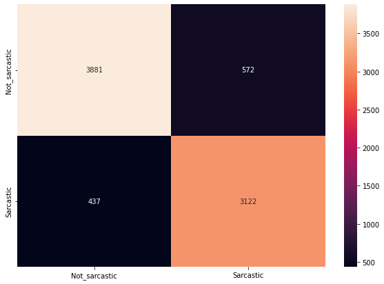

```python
import seaborn as sn
import pandas as pd
import matplotlib.pyplot as plt

df_cm = pd.DataFrame(cm, index = [i for i in ['Not_sarcastic','Sarcastic']],
                                  columns = [i for i in ['Not_sarcastic','Sarcastic']])
plt.figure(figsize = (10,7))
sn.heatmap(df_cm, annot=True, fmt = '1g')
```

```python
scores2 = model_2.evaluate(test_sequences, test_labels, verbose=0)
print("Accuracy: %.5f%%" % (scores2[1]*100))
```

```
Accuracy: 87.40639%
```

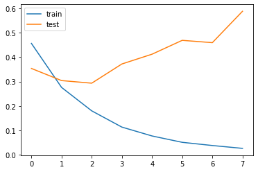

```python
from matplotlib import pyplot
pyplot.plot(history2.history['loss'], label='train')
pyplot.plot(history2.history['val_loss'], label='test')
pyplot.legend()
pyplot.show()
```

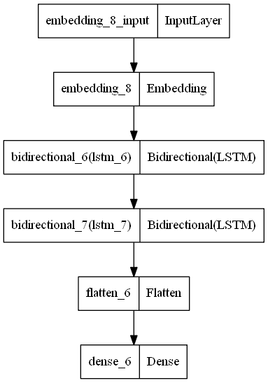

```python
plot_model(model_2)
```

## with stacked LSTM the has updated its accuracy from 86.5 to 87.4%

## Trying with 200d for embedding word

```python
import numpy as np

EMBEDDING_FILE = 'glove.6B.200d.txt'

embeddings = {}
for o in open(EMBEDDING_FILE,encoding="utf8"):
    word = o.split(" ")[0]
    # print(word)
    embd = o.split(" ")[1:]
    embd = np.asarray(embd, dtype='float32')
    # print(embd)
    embeddings[word] = embd

# create a weight matrix for words in training docs
embedding_matrix = np.zeros((num_words, 200))

for word, i in tokenizer.word_index.items():
	embedding_vector = embeddings.get(word)
	if embedding_vector is not None:
		embedding_matrix[i] = embedding_vector
```

```python
model_3 = Sequential()
#Non-trainable embeddidng layer
model_3.add(Embedding(num_words, 200, weights=[embedding_matrix], input_length=maxlen))
#LSTM
model_3.add(Bidirectional(LSTM(units=256 ,dropout = 0.4,return_sequences=True)))
model_3.add(Bidirectional(LSTM(units=128, dropout= 0.3)))
model_3.add(Dense(64,activation='relu'))
model_3.add(Dropout(0.1))
model_3.add(Flatten())
model_3.add(Dense(1, activation='sigmoid'))
# model.summary()

opt = keras.optimizers.Adam(learning_rate=0.01)
model_3.compile(optimizer=opt, loss='binary_crossentropy', metrics=["accuracy"])

history3=model_3.fit(x=training_sequences, y=training_labels, callbacks=[early_stopping],batch_size=32,validation_data=(test_sequences, test_labels), epochs = 30, verbose = 1)
```

```
Epoch 00007: early stopping
```

```python
#Test accuracy
print("Test-Accuracy:", np.mean(history3.history["val_accuracy"]))
```

```
Test-Accuracy: 0.8386527385030474
```

```python
scores3 = model_3.evaluate(test_sequences, test_labels, verbose=0)
print("Accuracy: %.5f%%" % (scores3[1]*100))
```

```
Accuracy: 83.81178%
```

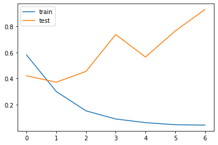

```python
from matplotlib import pyplot
pyplot.plot(history3.history['loss'], label='train')
pyplot.plot(history3.history['val_loss'], label='test')
pyplot.legend()
pyplot.show()
```